# A quick glimpse of riverbed

L. Vaudor

10 juillet 2018

```r
library(riverbed)
s1 <- tibble(l=c(1.1,3.4,5.0,5.3,6.2,4.3,2.5,6.7,6.9,9.2),
             z=c(1.4,3.1,5.5,4.8,1.3,2.5,4.3,2.2,3.1,2.6))
s2 <- tibble(l=c(0.5,2.5,4.0,6.0,4.4,5.8,9.5,7.2),
             z=c(2.8,1.5,2.2,4.3,5.5,2.2,1.5,5.3))
```

We consider two longitudinal series $s_1=(l_1,z_1)$, and $s_2=(l_2,z_2)$:

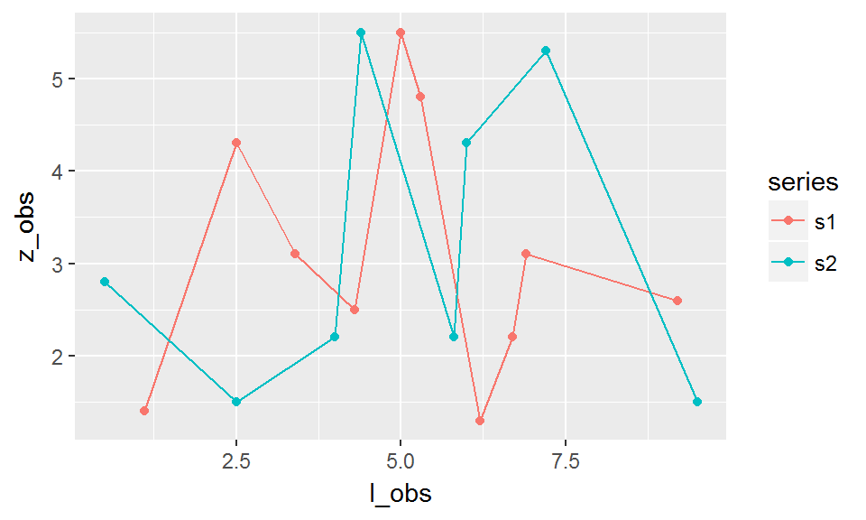

To calculate the area between the curves we need to interpolate the data and calculate intersects between the two curves:

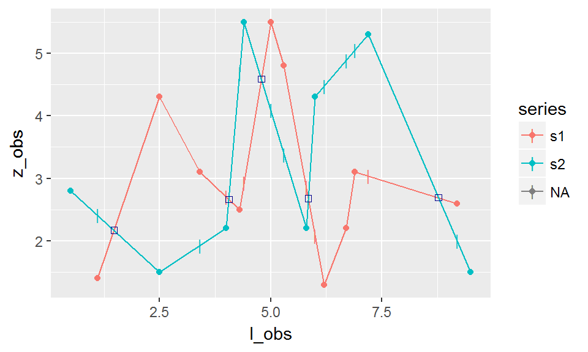

This, as well as the calculation of corresponding trapezia, is realised by the function `area_between()`.

```r
result_area <- area_between(s1,s2)
result_area
```

```
## $data
## # A tibble: 42 x 15
##        l    z1 p          z2       a type   l_obs z_obs series z1min z1max
##    <dbl> <dbl> <chr>   <dbl>   <dbl> <chr>  <dbl> <dbl> <chr>  <dbl> <dbl>
##  1 0.500 NA    observ~  2.80  NA     <NA>   0.500  2.80 s2        NA    NA
##  2 1.10   1.40 observ~  2.41   0     <NA>   1.10   1.40 s1        NA    NA
##  3 1.10   1.40 interp~  2.41 - 0.187 lower NA     NA    s2        NA    NA
##  4 1.47   2.17 inters~  2.17  NA     lower NA     NA    <NA>      NA    NA
##  5 1.47   2.17 inters~  2.17   1.44  upper NA     NA    <NA>      NA    NA
##  6 2.50   4.30 observ~  1.50   0     <NA>   2.50   4.30 s1        NA    NA
##  7 2.50   4.30 observ~  1.50   1.79  upper  2.50   1.50 s2        NA    NA
##  8 3.40   3.10 observ~  1.92   0     <NA>   3.40   3.10 s1        NA    NA
##  9 3.40   3.10 interp~  1.92   0.504 upper NA     NA    s2        NA    NA
## 10 4.00   2.70 interp~  2.20   0     <NA>  NA     NA    s1        NA    NA
## # ... with 32 more rows, and 4 more variables: z2min <dbl>, z2max <dbl>,
## #   lmin <dbl>, lmax <dbl>
##
## $area
## [1] -1.257652
##
## $area_by_type
## # A tibble: 2 x 2
##   type   area
##   <chr> <dbl>
## 1 lower -6.24
## 2 upper  4.99
##
## $sigma_area
## [1] 0
```

The output of the function corresponds to

- **total area** between curves (i.e. positive area - negative area)
- area between curves according to whether first curve is above the second curve (“**upper**”) or below (“**lower**”)
- data with all **coordinates** of interpolated points and intersects, used to calculate the area of trapezia (and which will be used by function `plot_area()`)

Note that it is also possible to calculate the area between one longitudinal series $s_1=(l_1,z_1)$ and a constant horizontal value $h$.

```r
result_area_h <- area_between(s1,h=2)
```

## Plot of area

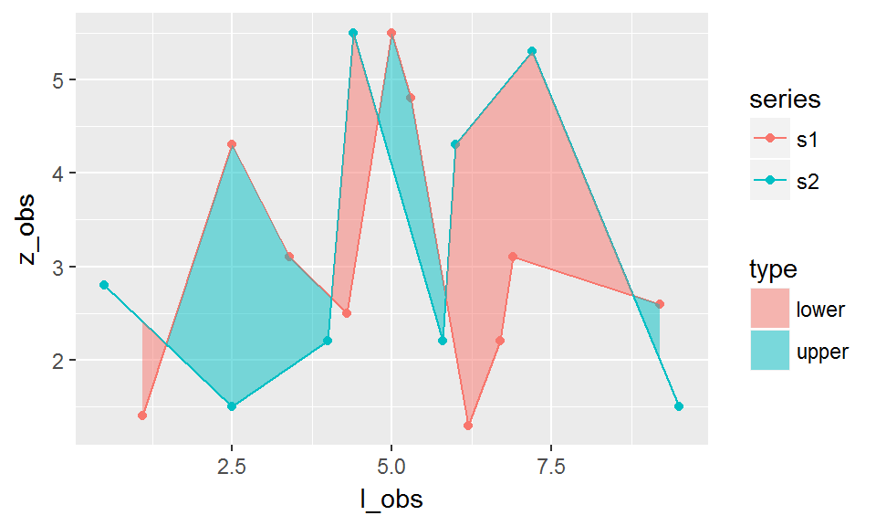

```r
plot_area(result_area)
```

If the distinction between upper and lower area is irrelevant then it is possible **not to distinguish these two types** on the plot:

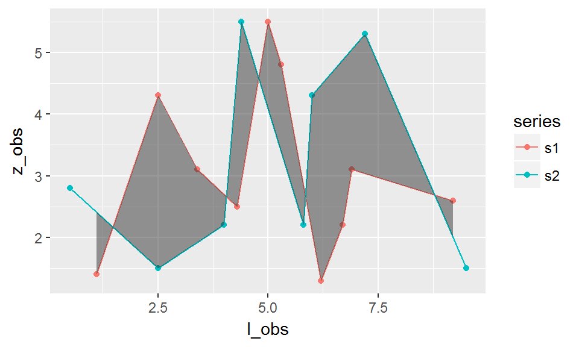

```r
plot_area(result_area,distinguish_type=FALSE)
```

The plotting function `plot_area()` can also be used with just **one series** and **constant horizontal level** $h$, as calculated earlier:

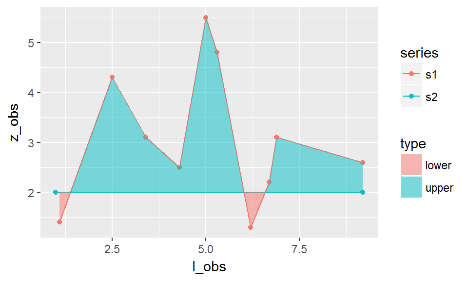

```r
plot_area(result_area_h)
```

# Error in the calculation of area

Now suppose that the series $s_1$ and $s_2$ are measured with a certain level of uncertainty, due to

- imprecision in the measure of height $z$ ($\sigma_z$) and/or
- imprecision in the measure of longitudinal coordinate $l$ ($\sigma_l$).

These imprecisions might be different for the two series (change in sampling protocol, improvement in sampling gear between two dates, etc.).

Here, with errors in the measures of height (0.1 and 0.3) higher than in the measures of longitudinal coordinates (0.05 and 0.2), and errors more important for series $s_2$ (0.3 and 0.2) than for $s_2$ (0.1 and 0.05).

```r
result_area <- area_between(s1,s2,
                            sigma_z=c(0.1,0.3),
                            sigma_l=c(0.05,0.2))
```

The `plot_area()` function can provide a visual hint of the uncertainties in $l$ and $z$ measures with horizontal and vertical error bars:

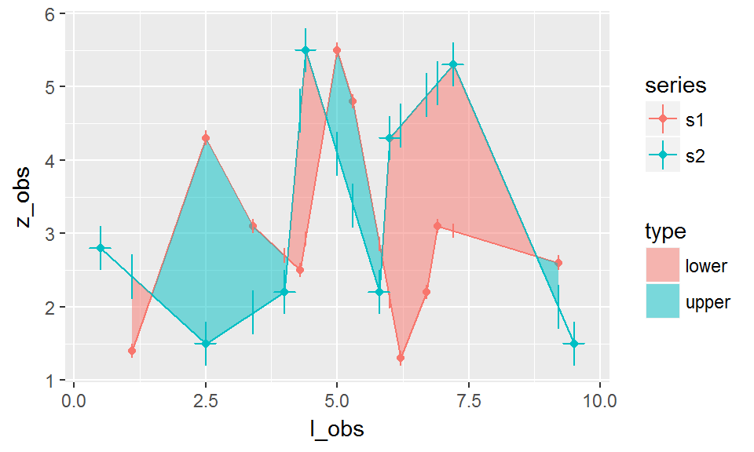

```r
plot_area(result_area, show_uncertainty=TRUE)
```

We can check the calculation of error through a simple simulation with 1000 series $s_{1tmp}$ and $s_{2tmp}$ varying around $s_1$ and $s_2$ respectively, with variations corresponding to estimation errors $\sigma_z$ and $\sigma_l$:

```r
set.seed(33)
sigma_z=c(0.1,0.3)
sigma_l=c(0.05,0.2)
f=function(i){
  s1_tmp <- tibble(l=s1$l+rnorm(nrow(s1),0,sigma_l[1]),
                   z=s1$z+rnorm(nrow(s1),0,sigma_z[1]))
  s2_tmp <- tibble(l=s2$l+rnorm(nrow(s2),0,sigma_l[2]),
                   z=s2$z+rnorm(nrow(s2),0,sigma_z[2]))
  return(area_between(s1_tmp,s2_tmp)$area)
}
area_vals=purrr::map_dbl(1:1000,f)
sd(area_vals)
```

```
## [1] 1.162812
```

```r
res=area_between(s1,s2,
                 sigma_z=sigma_z, sigma_l=sigma_l)
res$sigma_area
```

```
## [1] 1.099483
```